# Introduction to Preregistration

Sara Lil Middleton

Sara.Middleton@psy.lmu.de

LMU Open Science Center

Felix Schönbrodt

felix.schoenbrodt@psy.lmu.de

Ludwig-Maximilians-Universität München

2026-05-22

## Open Science in the research process

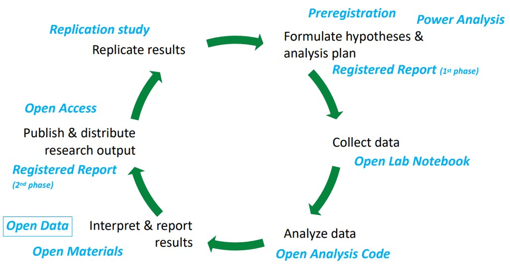

get all material here: https://osf.io/zjrhu/

## Threats to research validity …

### p-hacking & friends

| Threat | Remedy |
| --- | --- |
| Switching of primary outcome to a variable that “works better” | Publicly write down the primary outcome before data collection |
| HARKing: “Hypothesizing after results are known” | Publicly write down hypotheses before data collection |
| Flexibility in data analysis (e.g., trying out different outlier exclusions to see which “work best”) | Specify exclusion rules and the full analysis plan before seeing the data |

## Threats to research validity …

### Biases

| Threat label | Explanation | Remedy |
| --- | --- | --- |
| **Hindsight bias** | Tendency to frame previous decisions or events as more predictable after the outcome is known (“I knew it all along”) | Write down your hypotheses and analysis plans before you see the data |
| **Confirmation bias** | Tendency to seek out, interpret, favor and recall information in a way that supports one’s prior expectations | Write down your decision rules and analysis plan before you see the data |

## *Preregistration* is the specification of …

- the research design (including sample size planning),
- operationalizations,
- hypotheses,
- analysis plan, and
- inferential criteria

… prior to observing the outcomes of a study.

adapted from Nosek & Lindsay (2018), PRP-QUANT template, and [RESQUE](https://www.resque.info/).

## Distinguishing confirmatory from exploratory analyses

**Confirmatory analysis**

- Number of hypothesis tests: Known.
- Error rate control: Possible.
- *p*-value: Meaningful.

**Exploratory analysis**

- Number of hypothesis tests: Unknown.
- Error rate control: Impossible.
- *p*-value: “essentially uninterpretable”.

Wasserstein, R. L., & Lazar, N. A. (2016). The ASA Statement on p -Values: Context, Process, and Purpose. The American Statistician, 70(2), 129–133. https://doi.org/10.1080/00031305.2016.1154108

## Convince others that you did not engage in QRPs

### How can you convince a *skeptical* reader?

- Publish your preregistration openly
- Use a third-party platform that freezes the file (so that you cannot edit it later) with a timestamp
- Nullius in verba: The less trust is necessary, the more convincing.

Discuss: What challenge does a secondary data analysis (from an existing dataset) pose?

## Why do we preregister?

### Summary

1. **Don’t do QRPs**: Safeguard ourselves from (unconscious) biases and QRPs
2. **Convince others that you did no QRPs**: Build your reputation (pre-diction instead of post-diction; transparency)
3. **Restrict your degrees of freedom**: Clearly distinguish confirmatory from exploratory results
4. **Intended side-effect**: We think more clearly about our design and data collection *before* we start collecting data → quality improvements.

## Registered Report

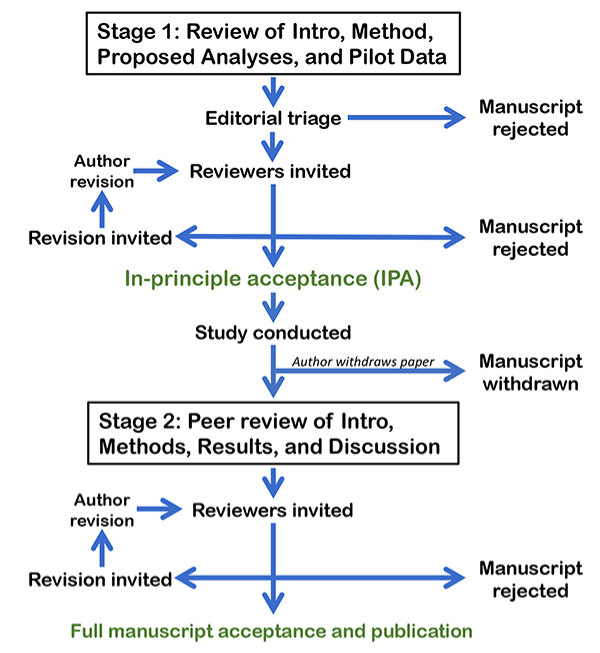

# Elements of a preregistration

## Elements of a preregistration

### 1. Hypotheses

✅ **Essential**:

- Describe hypotheses as relationships between variables
- Describe shape of interaction effects
- Describe manipulation checks (or why they are not included)

☑️ **Recommended**:

- Figures / tables to describe interaction effects
- Rationales / theoretical frameworks to justify the hypotheses

van t‘Veer & Giner-Sorolla (2016)

## Elements of a preregistration

### 2. Operationalizations

✅ **Essential**:

- List, based on your hypotheses,
  - Independent variables (describe variable, all levels, between- or within-person?)
  - Dependent variables
  - Third variables (covariates, moderators, control variables etc.)

van t‘Veer & Giner-Sorolla (2016)

## Elements of a preregistration

### 3. Planned sample

✅ **Essential**:

- Pre-selection rules (e.g., age limits)
- Where, from whom, and how will the data be collected?
- Justify planned sample size (power analysis or Bayesia design analysis)
- Describe data collection termination rule

van t‘Veer & Giner-Sorolla (2016), Schönbrodt & Wagenmakers (2017)

## Elements of a preregistration

### 4. Exclusion criteria

✅ **Essential**:

- Describe all anticipated exclusion criteria, e.g.
  - Missing, erroneous, overly consistent responses
  - Failing check-tests or suspicion probes
  - Demographic exclusions
  - Data-based outlier criteria
  - Method-based outlier criteria (e.g., too long response times)

☑️ **Recommended**:

- Set fail-save levels of exclusion at which whole study needs to be stopped, altered, and restarted

van t‘Veer & Giner-Sorolla (2016)

## Elements of a preregistration

### 5. Analysis plan

✅ **Essential**:

- Describe statistical analyses that test hypotheses. For each, include
  - Relevant variables and how they are calculated
  - Statistical technique
  - Each variable‘s role in the technique (e.g., IV, DV, covariate, …)
  - If covariates are used: Rationale for using them
  - Describe inferential criteria (i.e., when will you accept or reject a hypothesis?). This is typically the $\alpha$ level and whether you test one- or two-sided.

van t‘Veer & Giner-Sorolla (2016)

## Elements of a preregistration

### 5. Analysis plan

☑️ **Recommended**:

- Specify contingencies and assumptions, such as
  - Method of correcting for multiple testing
  - Method of missing data handling
  - Anticipated data transformations
  - Assumptions and assumption checks for analyses and alternative plans for data analysis if assumptions are not met

van t‘Veer & Giner-Sorolla (2016)

## Elements of a preregistration

### 6. Additional stuff

☑️ **Recommended**:

- For exploratory analyses: “We don‘t have any hypotheses”
- Transparency statement: How will research output be shared?
- Conditional safeguards: What will happen if…?

Lin & Green (2016)

## Preregistration templates

Recommended:

- The **Preregistration for Quantitative Research in Psychology Template (PRP-QUANT)** was developed in a joint effort by a task force composed of members of the APA, BPS, DGPs, the COS, and ZPID.
- https://prereg-psych.org/index.php/rrp/templates

## Preregistration templates (alternatives)

- [van t‘Veer, A.E. & Giner-Sorolla, R. (2016)](https://pages.cs.wisc.edu/~jerryzhu/HAMLET/psyreplicability/van_'t_Veer&Giner-Sorolla2016.pdf)
- [aspredicted.org](https://aspredicted.org/)
- [Replication Recipe (for replication studies)](https://www.researchgate.net/publication/259090892_The_Replication_Recipe_What_Makes_for_a_Convincing_Replication)
- [BAM!!!Lab Study preregistration](https://osf.io/ghu7y)
- [OSF preregistration challenge](https://osf.io/jea94)
- [Happy Lab Preregistration (quite short)](https://osf.io/5k639)
- …

## A curated list of high quality preregistrations

- https://osf.io/e6auq/wiki/Example%20Preregistrations/

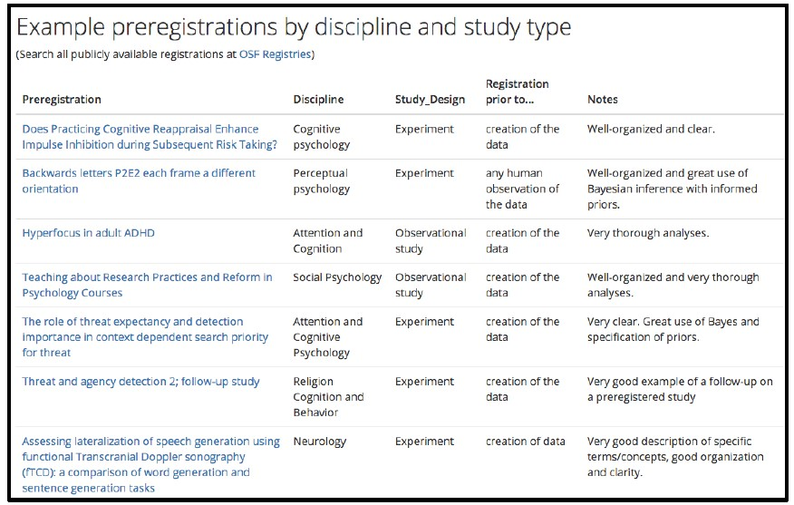

# End